# CovCombR: Combining Incomplete Covariance Matrices

Deniz Akdemir

2026-06-30

# CovCombR in One Example

The CovCombR package combines several incomplete covariance matrices (each covering different subsets of variables) into a single, coherent estimate. The default model automatically selects an appropriate factor structure via BIC, which handles cases where some variable pairs are never observed together in the same study.

## The Identifiability Problem

Before fitting, it is important to understand when a combined estimate is *identified* — meaning the data uniquely determine the answer rather than just reflecting an arbitrary starting value.

With the **unconstrained (free-Σ) model**, a covariance σ_ij is identifiable only if variables *i* and *j* are jointly observed in at least one study. If they never appear together, σ_ij is absent from the likelihood and the estimate is initialization-dependent.

With a **factor model** (Σ = ΛΛᵀ + Ψ), this constraint is relaxed: even if variables *i* and *j* are never jointly observed, their loadings Λ[i,·] and Λ[j,·] can both be identified through their relationships with shared overlapping variables, so σ_ij = Λ[i,·]·Λ[j,·] becomes identified.

The default `n_factors = "auto"` fits factor models of increasing complexity alongside the free model and selects the best by BIC, giving you the most parsimonious *identifiable* representation of the data.

## Scenario: Block-Structured Covariance with Overlapping Samples

We simulate a covariance matrix with two correlated blocks. Ten independent studies each observe a different overlapping subset of variables. The study patterns deliberately include some pairs never jointly observed, which makes the free-Σ model non-identifiable for those pairs.

```r
set.seed(1234)
p <- 8
var_names <- paste0("Var", seq_len(p))

# True covariance with block structure and heterogeneous variances
block <- matrix(0.6, 4, 4); diag(block) <- 1
true_cov <- matrix(0, p, p)
true_cov[1:4, 1:4] <- block
true_cov[5:8, 5:8] <- block
true_cov[1:4, 5:8] <- 0.2; true_cov[5:8, 1:4] <- 0.2
diag(true_cov) <- 1
std_dev <- c(1.5, 1.2, 1.8, 1.4, 2.0, 1.6, 1.3, 1.9)
true_cov <- diag(std_dev) %*% true_cov %*% diag(std_dev)
dimnames(true_cov) <- list(var_names, var_names)

# Observation patterns — sparse enough that some pairs are never jointly observed
patterns <- list(
  sample1  = var_names[c(1, 2)],
  sample2  = var_names[c(3, 4)],
  sample3  = var_names[c(5, 6)],
  sample4  = var_names[c(7, 8)],
  sample5  = var_names[c(1, 3, 5)],
  sample6  = var_names[c(2, 4, 6)],
  sample7  = var_names[c(3, 5, 7)],
  sample8  = var_names[c(2, 6, 8)],
  sample9  = var_names[c(1, 4, 7)],
  sample10 = var_names[c(2, 5, 8)]
)
nu <- setNames(sample(70:110, length(patterns), replace = TRUE), names(patterns))

S_list <- lapply(names(patterns), function(nm) {
  vars <- patterns[[nm]]
  W_block <- rWishart(1, nu[[nm]], true_cov[vars, vars])[,,1]
  S_block <- W_block / nu[[nm]]
  dimnames(S_block) <- list(vars, vars)
  S_block
})
names(S_list) <- names(patterns)
```

## Naive Stitching Leaves Large Gaps

A common first attempt averages overlapping blocks wherever they exist and leaves NAs elsewhere.

```r
cov_sum    <- matrix(0, p, p, dimnames = list(var_names, var_names))
pair_counts <- matrix(0, p, p, dimnames = list(var_names, var_names))

for (nm in names(S_list)) {
  vars <- rownames(S_list[[nm]])
  cov_sum[vars, vars]    <- cov_sum[vars, vars]    + S_list[[nm]]
  pair_counts[vars, vars] <- pair_counts[vars, vars] + 1
}

naive_cov <- matrix(NA, p, p, dimnames = list(var_names, var_names))
observed_pairs <- pair_counts > 0
naive_cov[observed_pairs] <- cov_sum[observed_pairs] / pair_counts[observed_pairs]
```

## CovCombR Recovers the Missing Structure

The default call uses `n_factors = "auto"`, which selects the best factor model by BIC and ensures an identifiable estimate even for variable pairs never jointly observed.

```r
fit <- fit_covcomb(S_list, nu, se_method = "none")

fit$n_factors
```

```
## [1] 2
```

```r
fit$ic_table
```

```
##   n_factors    loglik n_params      AIC      BIC selected
## 1         1 -304.3857       16 640.7714 717.5919    FALSE
## 2         2 -217.6656       23 481.3313 591.7608     TRUE
## 3         3 -226.8419       29 511.6837 650.9209    FALSE
## 4         4 -221.9458       34 511.8916 675.1353    FALSE
## 5        NA -214.6224       36 501.2448 674.0910    FALSE
```

```r
Sigma_hat <- coef(fit)[var_names, var_names]
S_hat     <- fitted(fit)[var_names, var_names]
em_cov    <- S_hat
```

The `ic_table` shows all candidate models (rows) with their BIC values, so you can see exactly why the selected factor count was chosen. The selected model’s `Sigma_hat` is an identifiable estimate of the full covariance structure.

## Visual Comparison: True vs. Naive vs. CovCombR

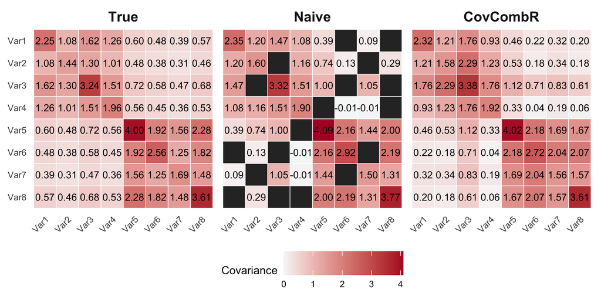

```r
get_plot_data <- function(mat, label) {
  as.data.frame(mat) |>
    rownames_to_column("row") |>
    tidyr::pivot_longer(-row, names_to = "col", values_to = "value") |>
    mutate(matrix = label)
}

plot_data <- bind_rows(
  get_plot_data(true_cov, "True"),
  get_plot_data(naive_cov, "Naive"),
  get_plot_data(em_cov, "CovCombR")
)

plot_data$row    <- factor(plot_data$row,    levels = rev(var_names))
plot_data$col    <- factor(plot_data$col,    levels = var_names)
plot_data$matrix <- factor(plot_data$matrix, levels = c("True", "Naive", "CovCombR"))

ggplot(plot_data, aes(x = col, y = row, fill = value)) +
  geom_tile(color = "white", linewidth = 0.2) +
  geom_text(aes(label = ifelse(is.na(value), "", sprintf("%.2f", value))),
            size = 2.5, na.rm = TRUE) +
  scale_fill_gradient2(midpoint = 0, na.value = "#2F2F2F",
                       low = "#2166AC", high = "#B2182B", mid = "#F7F7F7",
                       name = "Covariance") +
  facet_wrap(~matrix, nrow = 1) +
  coord_equal() +
  labs(x = NULL, y = NULL) +
  theme_minimal(base_size = 8) +
  theme(panel.grid = element_blank(),
        strip.text = element_text(face = "bold", size = 10),
        axis.text.x = element_text(angle = 45, hjust = 1),
        legend.position = "bottom")
```

CovCombR reconstructs the full block pattern, while the naive stitch lacks estimates for any variable pair never observed together (grey tiles).

## Correlation Comparison

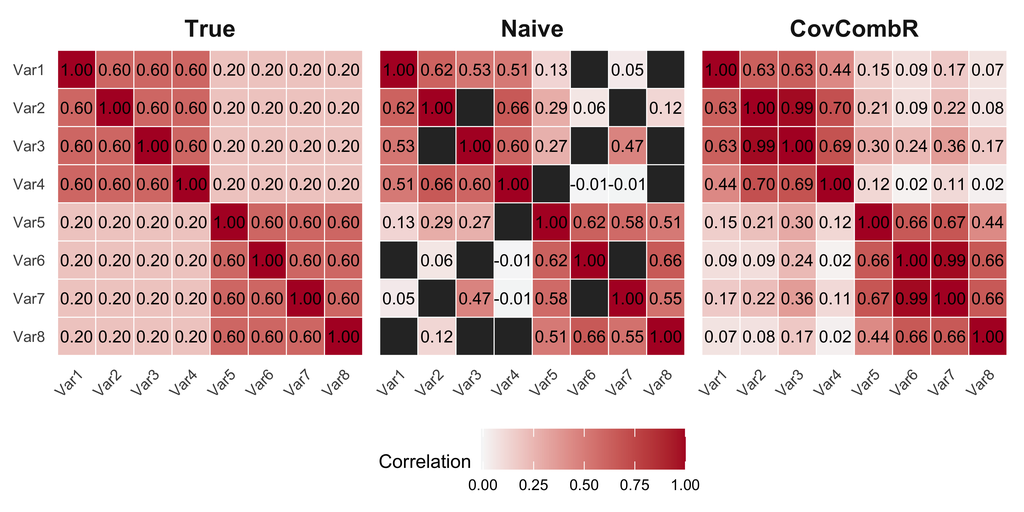

```r
true_corr <- cov2cor(true_cov)
em_corr   <- cov2cor(em_cov)
naive_corr <- naive_cov
for (i in 1:p) {
  for (j in 1:p) {
    if (!is.na(naive_cov[i, i]) && !is.na(naive_cov[j, j]) && !is.na(naive_cov[i, j])) {
      naive_corr[i, j] <- naive_cov[i, j] / sqrt(naive_cov[i, i] * naive_cov[j, j])
    }
  }
}

corr_plot_data <- bind_rows(
  get_plot_data(true_corr,  "True"),
  get_plot_data(naive_corr, "Naive"),
  get_plot_data(em_corr,    "CovCombR")
)
corr_plot_data$row    <- factor(corr_plot_data$row,    levels = rev(var_names))
corr_plot_data$col    <- factor(corr_plot_data$col,    levels = var_names)
corr_plot_data$matrix <- factor(corr_plot_data$matrix, levels = c("True", "Naive", "CovCombR"))

ggplot(corr_plot_data, aes(x = col, y = row, fill = value)) +
  geom_tile(color = "white", linewidth = 0.2) +
  geom_text(aes(label = ifelse(is.na(value), "", sprintf("%.2f", value))),
            size = 2.5, na.rm = TRUE) +
  scale_fill_gradient2(midpoint = 0, na.value = "#2F2F2F",
                       low = "#2166AC", high = "#B2182B", mid = "#F7F7F7",
                       name = "Correlation") +
  facet_wrap(~matrix, nrow = 1) +
  coord_equal() +
  labs(x = NULL, y = NULL) +
  theme_minimal(base_size = 8) +
  theme(panel.grid = element_blank(),
        strip.text = element_text(face = "bold", size = 10),
        axis.text.x = element_text(angle = 45, hjust = 1),
        legend.position = "bottom")
```

## Recovery Quality in Numbers

```r
upper_tri        <- upper.tri(true_cov, diag = TRUE)
observed_tri     <- observed_pairs & upper_tri
unobserved_tri   <- (!observed_pairs) & upper_tri

coverage_pct <- round(100 * sum(observed_tri) / sum(upper_tri), 1)

stats_tbl <- tibble(
  Estimator = c("Naive stitch", "CovCombR", "CovCombR"),
  Pairs     = c("Observed Only", "Observed Only", "Unobserved Only"),
  RMSE = c(
    sqrt(mean((naive_cov[observed_tri] - true_cov[observed_tri])^2, na.rm = TRUE)),
    sqrt(mean((em_cov[observed_tri]   - true_cov[observed_tri])^2)),
    sqrt(mean((em_cov[unobserved_tri] - true_cov[unobserved_tri])^2))
  ),
  MAE = c(
    mean(abs(naive_cov[observed_tri] - true_cov[observed_tri]), na.rm = TRUE),
    mean(abs(em_cov[observed_tri]   - true_cov[observed_tri])),
    mean(abs(em_cov[unobserved_tri] - true_cov[unobserved_tri]))
  )
) |> mutate(across(where(is.numeric), ~round(.x, 3)))

knitr::kable(stats_tbl, caption = "Recovery accuracy on the covariance scale.")
```

Recovery accuracy on the covariance scale.

| Estimator | Pairs | RMSE | MAE |
| --- | --- | --- | --- |
| Naive stitch | Observed Only | 0.251 | 0.217 |
| CovCombR | Observed Only | 0.235 | 0.191 |
| CovCombR | Unobserved Only | 0.485 | 0.374 |

## Overriding the Automatic Selection

The auto selection is appropriate for most situations. When you want explicit control:

```r
# Fit a specific 2-factor model
fit_2f <- fit_covcomb(S_list, nu, n_factors = 2, se_method = "none")

# Fit the unconstrained free-Sigma model (requires all pairs observed)
fit_free <- fit_covcomb(S_list, nu, n_factors = NULL, se_method = "none")

# Use AIC instead of BIC for auto selection
fit_aic <- fit_covcomb(S_list, nu,
                       n_factors = "auto",
                       control = list(ic = "AIC"),
                       se_method = "none")
```

**When to use the free model (`n_factors = NULL`):** If your study design ensures every variable pair is jointly observed in at least one study, the free model is valid and places no factor-structure assumption on the data.

**When to specify a fixed k:** If you have domain knowledge about the number of latent factors (e.g., a known number of principal components), use that directly.